# Research on Parenting, and Statistical Materials

Andy Grogan-Kaylor https://agrogan1.github.io/ (University of Michigan)https://umich.edu/  
2019-09-10

### Table of Contents

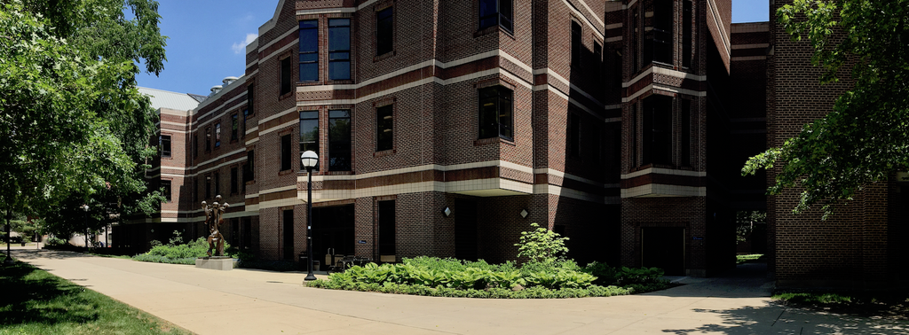

# My Background

A little bit about my background

# “Blog-ish” Posts

- [posts](https://agrogan1.github.io/myposts/)

| modified | url |
| --- | --- |
| 2019-04-25T14:58:59Z | bar_charts_and_pie_charts.html |
| 2019-04-25T14:59:19Z | bar_charts_in_ggplot2.html |
| 2019-02-22T18:19:00Z | bar-charts-in-ggplot-with-multiple-outcomes.html |
| 2019-08-26T19:15:11Z | comparing-program-outcomes-with-ggplot2.html |
| 2019-09-03T15:25:58Z | data-visualization-for-political-social-work.html |
| 2019-08-26T19:34:04Z | index.html |
| 2019-02-17T16:07:24Z | new_paper_on_corporal_punishment.html |
| 2019-02-17T16:05:42Z | order-of-operations-in-ggplot.html |
| 2019-06-24T16:45:54Z | quick-look-at-how-dates-work-in-R.html |
| 2019-02-17T16:06:24Z | reshaping-data-in-R-with-tidyr.html |

[output cut: 2 more lines]

# Courses

- [Multilevel and Longitudinal Modeling](https://agrogan1.github.io/multilevel/)

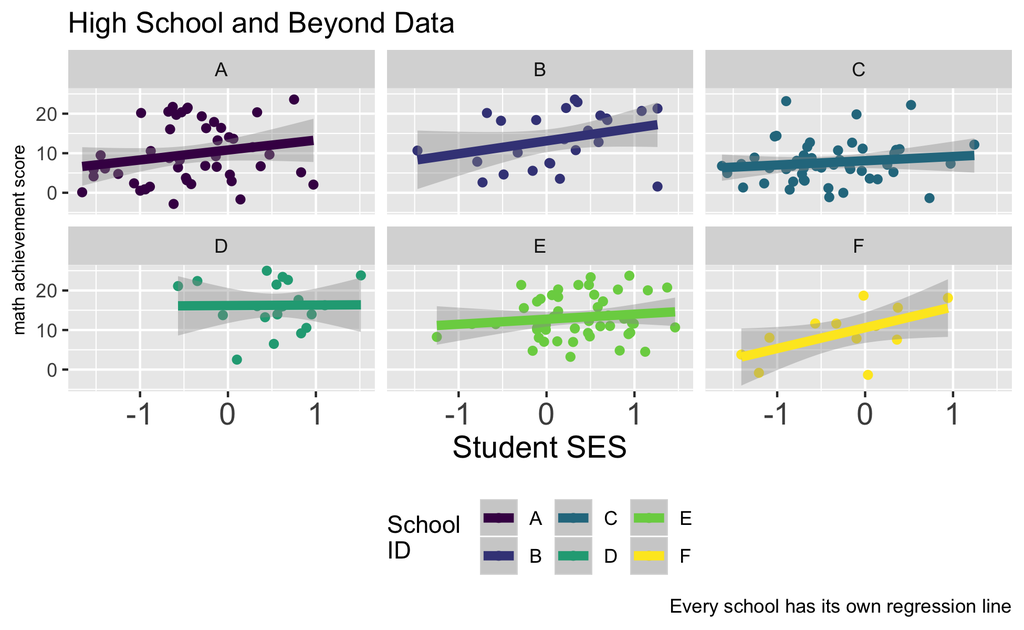

# Research on Parenting

- [Data Visualization](https://agrogan1.github.io/research/MICS1/) for “Spanking and young children’s socioemotional development in low- and middle-income countries”. *Child Trends News Service* has released a well done [video summarizing this research](https://youtu.be/8LYZ-UpR5wE).
- [Research On Corporal Punishment](https://agrogan1.github.io/research/cp/)
- Data Visualization of [Country Level Bans on Corporal Punishment](https://agrogan1.github.io/research/cpbans/)

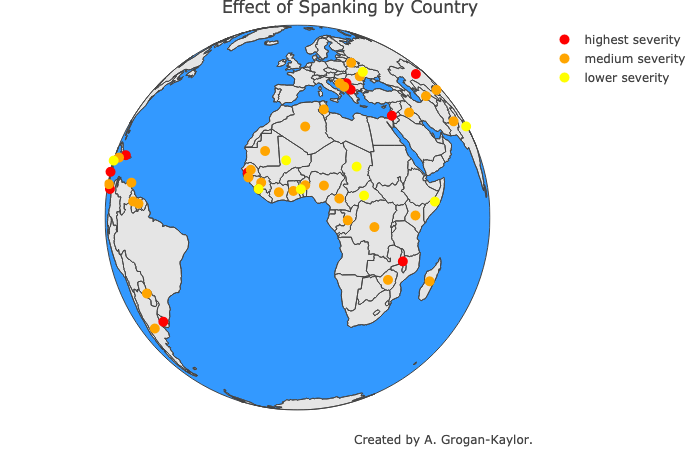

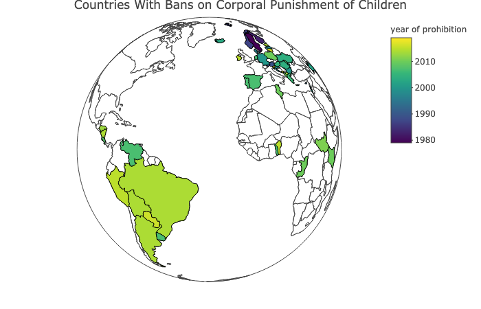

# Selected Collaborations

- Work with [Performance Measurement Initiative](https://agrogan1.github.io/research/performance-measurement-initiative) at William Davidson Institute

# R Materials

- *Introduction to R*:
  - [HTML Web Book](https://agrogan1.github.io/R/introduction-to-R/background.html)
  - [PDF](https://agrogan1.github.io/R/introduction-to-R/introduction-to-R.pdf)
  - epub
- *Introduction to ggplot2*:
  - [HTML Web Book](https://agrogan1.github.io/R/introduction-to-ggplot2/background.html)
  - [PDF](https://agrogan1.github.io/R/introduction-to-ggplot2/introduction-to-ggplot2.pdf)
  - epub
- University of Michigan colors for R Graphs:
  - [web page](https://agrogan1.github.io/R/michigancolors-demo/michigancolors-demo.html)
  - [R package](https://agrogan1.github.io/michigancolors/)
- *Two Page R*:
  - [PDF](https://agrogan1.github.io/R/two-page-R/two-page-R.pdf)
- *Two Page ggplot2*:
  - [PDF](https://agrogan1.github.io/R/two-page-ggplot2/two-page-ggplot2.pdf)
- *Five Page dplyr*:
  - [PDF](https://agrogan1.github.io/R/five-page-dplyr/five-page-dplyr.pdf)
  - [HTML](https://agrogan1.github.io/R/five-page-dplyr/five-page-dplyr.html)
- *Comparing Program Outcomes with ggplot2*
  - [HTML](https://agrogan1.github.io/myposts/comparing-program-outcomes-with-ggplot2.html)
  - [PDF](https://agrogan1.github.io/myposts/comparing-program-outcomes-with-ggplot2.pdf)
- *Working With Data From the World Bank Indicators*
  - [HTML](https://agrogan1.github.io/R/wbdemo/)

# Stata Materials

- *Two Page Stata*:
  - [HTML](https://agrogan1.github.io/Stata/two-page-stata/TwoPageStata.html)
  - [PDF](https://agrogan1.github.io/Stata/two-page-stata/TwoPageStata.pdf)
  - epub
- [“Michigan Graph Scheme” for Stata](https://agrogan1.github.io/Stata/)
- [Better Graphing in Stata](https://agrogan1.github.io/Stata/stata-graphing/)
- [Miscellaneous Stata Programs](https://agrogan1.github.io/Stata/)

# Bayesian Statistics

- [Demonstration of Bayesian Ideas](https://agrogan.shinyapps.io/shinyBayes/)
- [Bayesian Calculations](https://agrogan1.github.io/Bayes/) [[Draft Interactive Version](https://agrogan.shinyapps.io/shinyBayes2/)]

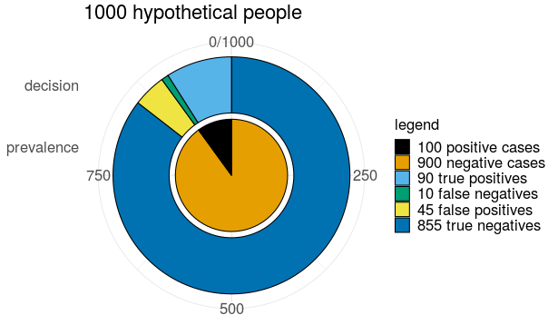

# Statistical Visualizations

- [t-test](https://agrogan.shinyapps.io/shiny-t-test/)
- [correlation](https://agrogan.shinyapps.io/correlation_demo/)
- [regression](https://agrogan.shinyapps.io/regression_demo/)
- [logistic regression](https://agrogan.shinyapps.io/exploring_logistic_regression/)
- [Cohen’s d Calculator](https://agrogan.shinyapps.io/effect_size_calculator/)

# Data Visualization

- [How to Choose a Chart: A Visual Guide](https://agrogan1.github.io/dataviz/how-to-choose-a-chart/how-to-choose-a-chart-a-visual-guide.pdf). [[Extended Version](https://agrogan1.github.io/dataviz/how-to-choose-a-chart/how-to-choose-a-chart-v3.html)]
- [Variables and Visualization](https://agrogan1.github.io/dataviz/variables-and-visualization/variables-and-visualization.html#/)
- [Graphing Change Over Time](https://agrogan1.github.io/dataviz/graphing-change-over-time/index.html) [[PDF](https://agrogan1.github.io/dataviz/graphing-change-over-time/index.pdf)]
- Slides for a Lecture on [Data Visualization for Political Social Work](https://agrogan1.github.io/dataviz/political-social-work/)

# Created By

Andrew Grogan-Kaylor

- https://umich.edu/~agrogan
- agrogan@umich.edu